# Risk Factor Analysis

## Outcome Variable

**Outcome Variable:** dead

## Predictor Variables

**Intervention Variable:** ever_underweight06

**Adjustment Set:**

unadjusted

## Stratifying Variables

The analysis was stratified on these variable(s):

- studyid
- country

## Data Summary

| studyid | country | ever_underweight06 | dead | n_cell | n |
| --- | --- | --- | --- | --- | --- |
| ki0047075b-MAL-ED | BANGLADESH | 0 | 0 | 182 | 263 |
| ki0047075b-MAL-ED | BANGLADESH | 0 | 1 | 1 | 263 |
| ki0047075b-MAL-ED | BANGLADESH | 1 | 0 | 79 | 263 |
| ki0047075b-MAL-ED | BANGLADESH | 1 | 1 | 1 | 263 |
| ki0047075b-MAL-ED | INDIA | 0 | 0 | 155 | 251 |
| ki0047075b-MAL-ED | INDIA | 0 | 1 | 1 | 251 |
| ki0047075b-MAL-ED | INDIA | 1 | 0 | 94 | 251 |
| ki0047075b-MAL-ED | INDIA | 1 | 1 | 1 | 251 |
| ki0047075b-MAL-ED | PERU | 0 | 0 | 258 | 302 |
| ki0047075b-MAL-ED | PERU | 0 | 1 | 2 | 302 |
| ki0047075b-MAL-ED | PERU | 1 | 0 | 42 | 302 |
| ki0047075b-MAL-ED | PERU | 1 | 1 | 0 | 302 |
| ki0047075b-MAL-ED | SOUTH AFRICA | 0 | 0 | 268 | 312 |
| ki0047075b-MAL-ED | SOUTH AFRICA | 0 | 1 | 0 | 312 |
| ki0047075b-MAL-ED | SOUTH AFRICA | 1 | 0 | 44 | 312 |
| ki0047075b-MAL-ED | SOUTH AFRICA | 1 | 1 | 0 | 312 |
| ki0047075b-MAL-ED | TANZANIA, UNITED REPUBLIC OF | 0 | 0 | 218 | 261 |
| ki0047075b-MAL-ED | TANZANIA, UNITED REPUBLIC OF | 0 | 1 | 2 | 261 |
| ki0047075b-MAL-ED | TANZANIA, UNITED REPUBLIC OF | 1 | 0 | 40 | 261 |
| ki0047075b-MAL-ED | TANZANIA, UNITED REPUBLIC OF | 1 | 1 | 1 | 261 |
| ki1000304b-SAS-CompFeed | INDIA | 0 | 0 | 896 | 1500 |
| ki1000304b-SAS-CompFeed | INDIA | 0 | 1 | 16 | 1500 |
| ki1000304b-SAS-CompFeed | INDIA | 1 | 0 | 568 | 1500 |
| ki1000304b-SAS-CompFeed | INDIA | 1 | 1 | 20 | 1500 |
| ki1000304b-SAS-FoodSuppl | INDIA | 0 | 0 | 211 | 401 |
| ki1000304b-SAS-FoodSuppl | INDIA | 0 | 1 | 2 | 401 |
| ki1000304b-SAS-FoodSuppl | INDIA | 1 | 0 | 186 | 401 |
| ki1000304b-SAS-FoodSuppl | INDIA | 1 | 1 | 2 | 401 |
| ki1017093b-PROVIDE | BANGLADESH | 0 | 0 | 480 | 699 |
| ki1017093b-PROVIDE | BANGLADESH | 0 | 1 | 3 | 699 |
| ki1017093b-PROVIDE | BANGLADESH | 1 | 0 | 215 | 699 |
| ki1017093b-PROVIDE | BANGLADESH | 1 | 1 | 1 | 699 |
| ki1066203-TanzaniaChild2 | TANZANIA, UNITED REPUBLIC OF | 0 | 0 | 2164 | 2395 |
| ki1066203-TanzaniaChild2 | TANZANIA, UNITED REPUBLIC OF | 0 | 1 | 1 | 2395 |
| ki1066203-TanzaniaChild2 | TANZANIA, UNITED REPUBLIC OF | 1 | 0 | 230 | 2395 |
| ki1066203-TanzaniaChild2 | TANZANIA, UNITED REPUBLIC OF | 1 | 1 | 0 | 2395 |
| ki1101329-Keneba | GAMBIA | 0 | 0 | 1913 | 2404 |
| ki1101329-Keneba | GAMBIA | 0 | 1 | 33 | 2404 |
| ki1101329-Keneba | GAMBIA | 1 | 0 | 435 | 2404 |
| ki1101329-Keneba | GAMBIA | 1 | 1 | 23 | 2404 |
| ki1113344-GMS-Nepal | NEPAL | 0 | 0 | 382 | 600 |
| ki1113344-GMS-Nepal | NEPAL | 0 | 1 | 2 | 600 |
| ki1113344-GMS-Nepal | NEPAL | 1 | 0 | 213 | 600 |
| ki1113344-GMS-Nepal | NEPAL | 1 | 1 | 3 | 600 |
| ki1126311-ZVITAMBO | ZIMBABWE | 0 | 0 | 11262 | 13813 |
| ki1126311-ZVITAMBO | ZIMBABWE | 0 | 1 | 661 | 13813 |
| ki1126311-ZVITAMBO | ZIMBABWE | 1 | 0 | 1524 | 13813 |
| ki1126311-ZVITAMBO | ZIMBABWE | 1 | 1 | 366 | 13813 |
| kiGH5241-JiVitA-3 | BANGLADESH | 0 | 0 | 15734 | 26675 |
| kiGH5241-JiVitA-3 | BANGLADESH | 0 | 1 | 240 | 26675 |
| kiGH5241-JiVitA-3 | BANGLADESH | 1 | 0 | 10413 | 26675 |
| kiGH5241-JiVitA-3 | BANGLADESH | 1 | 1 | 288 | 26675 |
| kiGH5241-JiVitA-4 | BANGLADESH | 0 | 0 | 3658 | 5076 |
| kiGH5241-JiVitA-4 | BANGLADESH | 0 | 1 | 15 | 5076 |
| kiGH5241-JiVitA-4 | BANGLADESH | 1 | 0 | 1385 | 5076 |
| kiGH5241-JiVitA-4 | BANGLADESH | 1 | 1 | 18 | 5076 |

The following strata were considered:

- studyid: ki0047075b-MAL-ED, country: BANGLADESH
- studyid: ki0047075b-MAL-ED, country: INDIA
- studyid: ki0047075b-MAL-ED, country: PERU
- studyid: ki0047075b-MAL-ED, country: SOUTH AFRICA
- studyid: ki0047075b-MAL-ED, country: TANZANIA, UNITED REPUBLIC OF
- studyid: ki1000304b-SAS-CompFeed, country: INDIA
- studyid: ki1000304b-SAS-FoodSuppl, country: INDIA
- studyid: ki1017093b-PROVIDE, country: BANGLADESH
- studyid: ki1066203-TanzaniaChild2, country: TANZANIA, UNITED REPUBLIC OF
- studyid: ki1101329-Keneba, country: GAMBIA
- studyid: ki1113344-GMS-Nepal, country: NEPAL
- studyid: ki1126311-ZVITAMBO, country: ZIMBABWE
- studyid: kiGH5241-JiVitA-3, country: BANGLADESH
- studyid: kiGH5241-JiVitA-4, country: BANGLADESH

### Dropped Strata

Some strata were dropped due to rare outcomes:

- studyid: ki0047075b-MAL-ED, country: BANGLADESH
- studyid: ki0047075b-MAL-ED, country: INDIA
- studyid: ki0047075b-MAL-ED, country: PERU
- studyid: ki0047075b-MAL-ED, country: SOUTH AFRICA
- studyid: ki0047075b-MAL-ED, country: TANZANIA, UNITED REPUBLIC OF
- studyid: ki1000304b-SAS-FoodSuppl, country: INDIA
- studyid: ki1017093b-PROVIDE, country: BANGLADESH
- studyid: ki1066203-TanzaniaChild2, country: TANZANIA, UNITED REPUBLIC OF
- studyid: ki1113344-GMS-Nepal, country: NEPAL

## Methods Detail

We’re interested in the causal parameters $E[Y_a]$ for all values of $a \in \mathcal{A}$. These parameters represent the mean outcome if, possibly contrary to fact, we intervened to set all units to have $A=a$. Under the randomization and positivity assumptions, these are identified by the statistical parameters $\psi_a=E_W[E_{Y|A,W}(Y|A=a,W)]$. In addition, we’re interested in the mean of $Y$, $E[Y]$ under no intervention (the observed mean). We will estimate these parameters by using SuperLearner to fit the relevant likelihood factors – $E_{Y|A,W}(Y|A=a,W)$ and $p(A=a|W)$, and then updating our likelihood fit using a joint TMLE.

For unadjusted analyses ($W=\{\}$), initial likelihoods were estimated using Lrnr_glm to estimate the simple $E(Y|A)$ and Lrnr_mean to estimate $p(A)$. For adjusted analyses, a small library containing Lrnr_glmnet, Lrnr_xgboost, and Lrnr_mean was used.

Having estimated these parameters, we will then use the delta method to estimate relative risks and attributable risks relative to a prespecified baseline level of $A$.

# Results Detail

## Results Plots

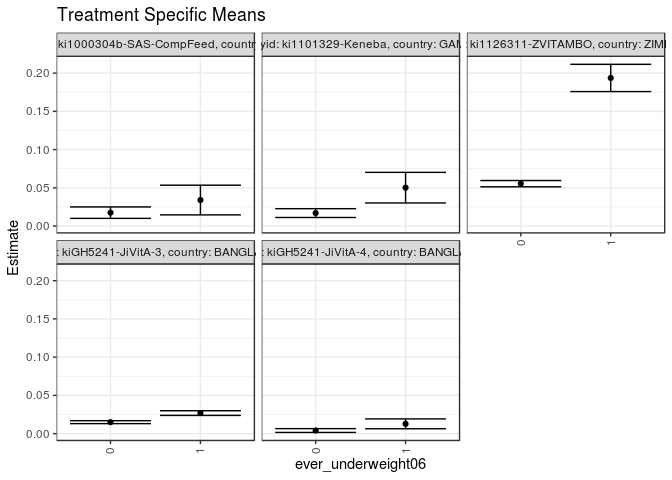

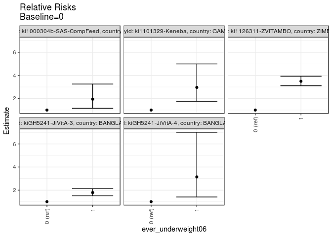

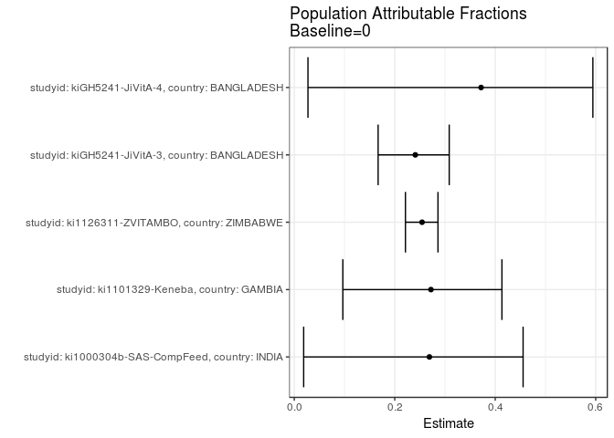

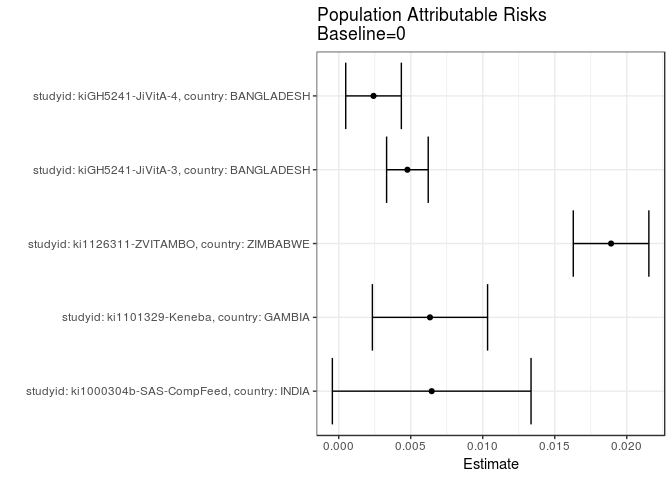

## Results Table

### Parameter: TSM

| studyid | country | intervention_level | baseline_level | estimate | ci_lower | ci_upper |
| --- | --- | --- | --- | --- | --- | --- |
| ki1000304b-SAS-CompFeed | INDIA | 0 | NA | 0.0175439 | 0.0100783 | 0.0250094 |
| ki1000304b-SAS-CompFeed | INDIA | 1 | NA | 0.0340136 | 0.0145778 | 0.0534494 |
| ki1101329-Keneba | GAMBIA | 0 | NA | 0.0169579 | 0.0112202 | 0.0226956 |
| ki1101329-Keneba | GAMBIA | 1 | NA | 0.0502183 | 0.0302129 | 0.0702238 |
| ki1126311-ZVITAMBO | ZIMBABWE | 0 | NA | 0.0554391 | 0.0513314 | 0.0595467 |
| ki1126311-ZVITAMBO | ZIMBABWE | 1 | NA | 0.1936508 | 0.1758350 | 0.2114665 |
| kiGH5241-JiVitA-3 | BANGLADESH | 0 | NA | 0.0150244 | 0.0130949 | 0.0169539 |
| kiGH5241-JiVitA-3 | BANGLADESH | 1 | NA | 0.0269134 | 0.0238627 | 0.0299640 |
| kiGH5241-JiVitA-4 | BANGLADESH | 0 | NA | 0.0040839 | 0.0015843 | 0.0065834 |
| kiGH5241-JiVitA-4 | BANGLADESH | 1 | NA | 0.0128297 | 0.0063598 | 0.0192995 |

### Parameter: E(Y)

| studyid | country | intervention_level | baseline_level | estimate | ci_lower | ci_upper |
| --- | --- | --- | --- | --- | --- | --- |
| ki1000304b-SAS-CompFeed | INDIA | NA | NA | 0.0240000 | 0.0131656 | 0.0348344 |
| ki1101329-Keneba | GAMBIA | NA | NA | 0.0232945 | 0.0172636 | 0.0293254 |
| ki1126311-ZVITAMBO | ZIMBABWE | NA | NA | 0.0743502 | 0.0699752 | 0.0787253 |
| kiGH5241-JiVitA-3 | BANGLADESH | NA | NA | 0.0197938 | 0.0180985 | 0.0214891 |
| kiGH5241-JiVitA-4 | BANGLADESH | NA | NA | 0.0065012 | 0.0039868 | 0.0090155 |

### Parameter: RR

| studyid | country | intervention_level | baseline_level | estimate | ci_lower | ci_upper |
| --- | --- | --- | --- | --- | --- | --- |
| ki1000304b-SAS-CompFeed | INDIA | 0 | 0 | 1.000000 | 1.000000 | 1.000000 |
| ki1000304b-SAS-CompFeed | INDIA | 1 | 0 | 1.938775 | 1.155881 | 3.251936 |
| ki1101329-Keneba | GAMBIA | 0 | 0 | 1.000000 | 1.000000 | 1.000000 |
| ki1101329-Keneba | GAMBIA | 1 | 0 | 2.961360 | 1.755902 | 4.994388 |
| ki1126311-ZVITAMBO | ZIMBABWE | 0 | 0 | 1.000000 | 1.000000 | 1.000000 |
| ki1126311-ZVITAMBO | ZIMBABWE | 1 | 0 | 3.493038 | 3.103859 | 3.931015 |
| kiGH5241-JiVitA-3 | BANGLADESH | 0 | 0 | 1.000000 | 1.000000 | 1.000000 |
| kiGH5241-JiVitA-3 | BANGLADESH | 1 | 0 | 1.791309 | 1.509870 | 2.125209 |
| kiGH5241-JiVitA-4 | BANGLADESH | 0 | 0 | 1.000000 | 1.000000 | 1.000000 |
| kiGH5241-JiVitA-4 | BANGLADESH | 1 | 0 | 3.141554 | 1.407881 | 7.010082 |

### Parameter: PAR

| studyid | country | intervention_level | baseline_level | estimate | ci_lower | ci_upper |
| --- | --- | --- | --- | --- | --- | --- |
| ki1000304b-SAS-CompFeed | INDIA | 0 | NA | 0.0064561 | -0.0004415 | 0.0133538 |
| ki1101329-Keneba | GAMBIA | 0 | NA | 0.0063366 | 0.0023374 | 0.0103359 |
| ki1126311-ZVITAMBO | ZIMBABWE | 0 | NA | 0.0189112 | 0.0162871 | 0.0215352 |
| kiGH5241-JiVitA-3 | BANGLADESH | 0 | NA | 0.0047694 | 0.0033245 | 0.0062143 |
| kiGH5241-JiVitA-4 | BANGLADESH | 0 | NA | 0.0024173 | 0.0004860 | 0.0043487 |

### Parameter: PAF

| studyid | country | intervention_level | baseline_level | estimate | ci_lower | ci_upper |
| --- | --- | --- | --- | --- | --- | --- |
| ki1000304b-SAS-CompFeed | INDIA | 0 | NA | 0.2690058 | 0.0187007 | 0.4554643 |
| ki1101329-Keneba | GAMBIA | 0 | NA | 0.2720232 | 0.0966562 | 0.4133460 |
| ki1126311-ZVITAMBO | ZIMBABWE | 0 | NA | 0.2543526 | 0.2212599 | 0.2860391 |
| kiGH5241-JiVitA-3 | BANGLADESH | 0 | NA | 0.2409541 | 0.1669010 | 0.3084246 |
| kiGH5241-JiVitA-4 | BANGLADESH | 0 | NA | 0.3718288 | 0.0272469 | 0.5943482 |